# Plankton, Ponds, and (Boosted) Trees

## Optimum trees; LR = 1 vs. 0.1

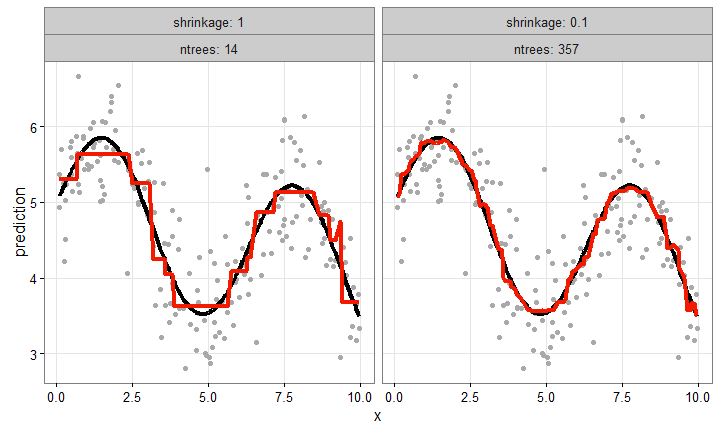

## Interaction depth

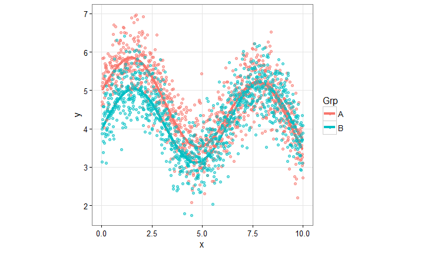

## Fitting a BRT with gbm()

## Data

```
## Source: local data frame [2,000 x 3]
##
##        x    Grp        y
##    (dbl) (fctr)    (dbl)
## 1   0.01      A 4.695773
## 2   0.01      B 3.135812
## 3   0.02      A 5.109820
## 4   0.02      B 3.864737
## 5   0.03      A 4.609181
## 6   0.03      B 3.999034
## 7   0.04      A 5.833630
## 8   0.04      B 4.128766
## 9   0.05      A 5.209733
## 10  0.05      B 4.242548
## ..   ...    ...      ...
```

## Two groups (interaction.depth = 1)

interaction.depth = 1 means *no interaction!*

```r
brt_id_1 <- gbm (y ~ x + Grp, data = dat2
            , n.trees = 1000
            , shrinkage = 0.1
            , interaction.depth = 1
            , cv.folds = 5)
```

## Model diagnostics

```r
brt_id_1
```

```
## gbm(formula = y ~ x + Grp, data = dat2, n.trees = 1000, interaction.depth = 1,
##     shrinkage = 0.1, cv.folds = 5)
## A gradient boosted model with gaussian loss function.
## 1000 iterations were performed.
## The best cross-validation iteration was 471.
## There were 2 predictors of which 2 had non-zero influence.
##
## Summary of cross-validation residuals:
##         0%        25%        50%        75%       100%
## -1.9250430 -0.3359167  0.0943870  0.5125533  2.1765444
##
## Cross-validation pseudo R-squared:  0.519
```

```r
best_iter <- gbm.perf(brt_id_1)
print(best_iter)
```

```
## [1] 471
```

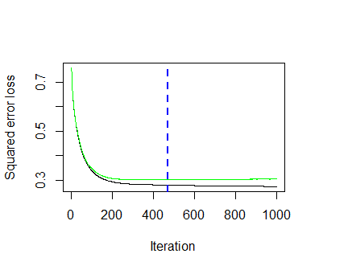

```r
summary(brt_id_1, n.trees = best_iter)
```

```
##     var   rel.inf
## x     x 93.766087
## Grp Grp  6.233913
```

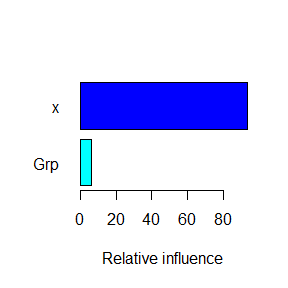

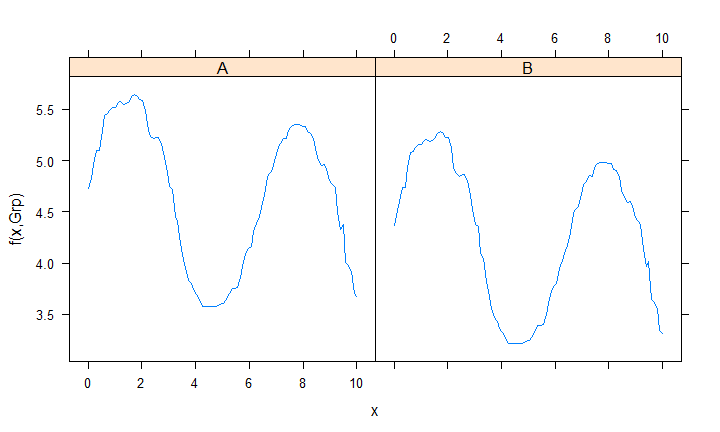

```r
plot(brt_id_1
     , n.trees = best_iter
     , i.var = 1:2, layout = c(2, 1))
```

```r
dat2$y_hat_id_1 <- predict(brt_id_1, n.trees = best_iter)
```

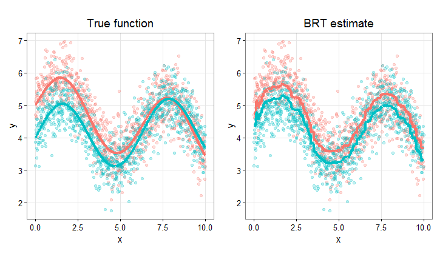

## Two groups (interaction.depth = 2)

```r
brt_id_2 <- gbm(y ~ x + Grp, data = dat2
            , n.trees = 1000
            , shrinkage = 0.1
            , interaction.depth = 2
            , cv.folds = 5)

best_iter2 <- gbm.perf(brt_id_2, plot.it = F)
```

```r
dat2$y_hat_id_2 <- predict(brt_id_2, n.trees = best_iter2)
```

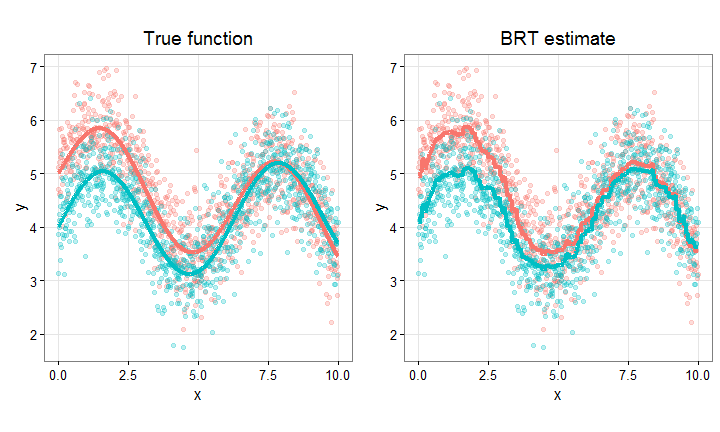

## Summary boosted trees

- Sum of long chain of simple trees iteratively fit to residuals
  - n.trees = how many trees to fit
  - shrinkage = learning rate ≊ regularization
  - interaction.depth ≊ tree depth ≊ base learner complexity
- Optimal size and complexity from test error (out of bag, OOB)
  - true test set or cross-validation
- R package *gbm* shown here - others available
- Checkout "The Elements of Statistical Learning: Data Mining, Inference, and Prediction" Hastie, T., Tibshirani, R., & Friedman, J. (2011)
  - legit .pdf copy available free online

## How I used boosted trees

## Lakes, phytoplankton, seasonal biovolume, effect of N & P

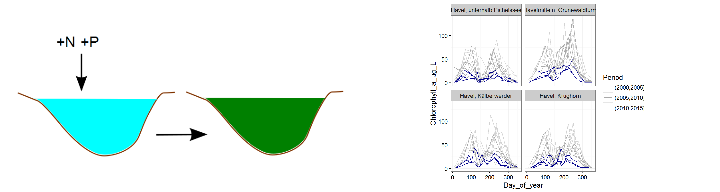

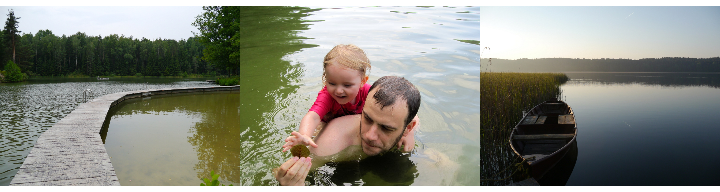

## Natural lakes in Germany

400+ lakes, > 5000 rows of data

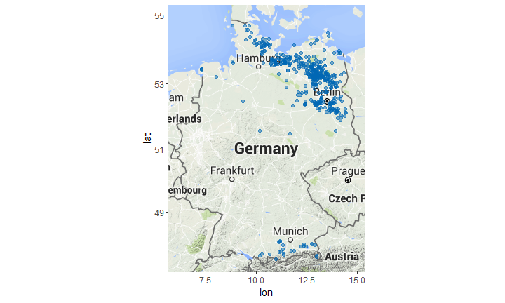

## Fit BRT with gbm()

```r
set.seed(07052015)

crs <- parallel:::detectCores() / 2

gbm_Total.5 <- gbm(Total ~ Week + log10_TN + log10_TP
                   + log10_Depth + Seen.Subtyp
            , distribution = list(name="quantile", alpha=0.5)
            , n.trees=10000, shrinkage = 0.01
            , cv.folds = 5, interaction.depth = 5
            , data = boost_dat_padded, n.cores = crs)
```

## Nutrient regimes

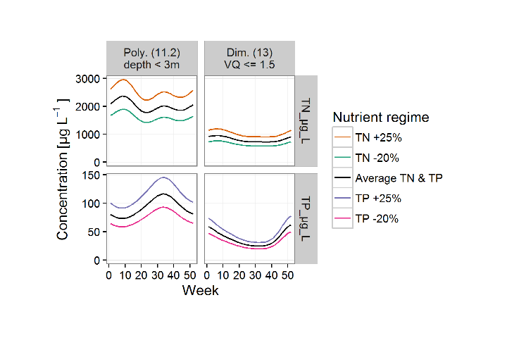

## Nutrient regimes

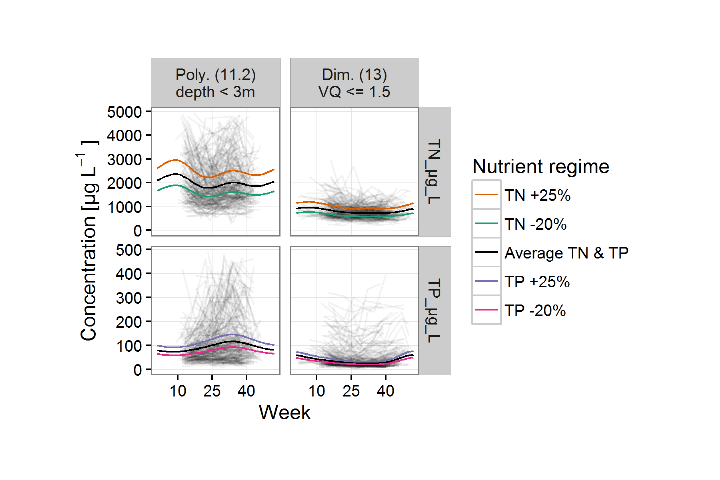

## Seasonal biovolume

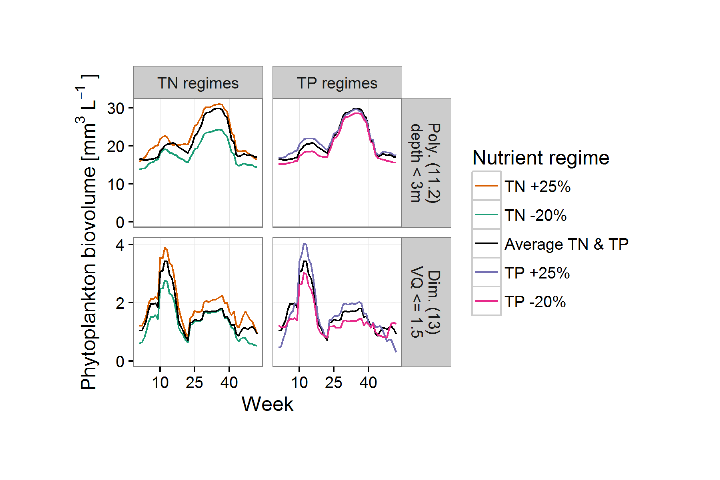

## P vs. N effect

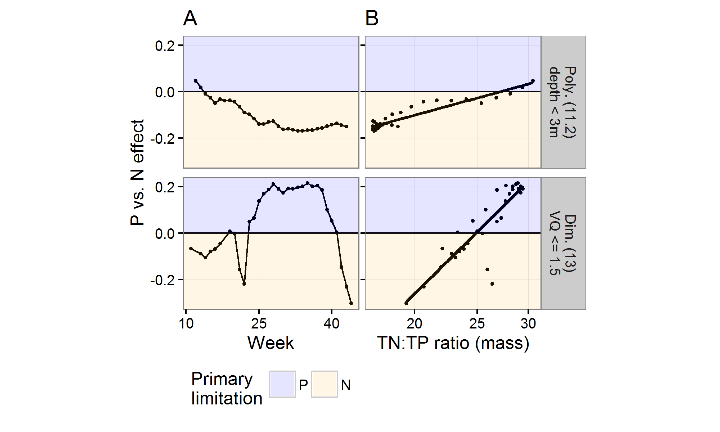

## Summary

- Boosted trees -> complex patterns and interactions
- N:P ratio effects emerge from "unstructured" model
- Sum of long chain of simple trees iteratively fit to residuals
- *R* package *gbm* - others available
- Checkout "The Elements of Statistical Learning: Data Mining, Inference, and Prediction" Hastie, T., Tibshirani, R., & Friedman, J. (2011)
  - legit .pdf copy available free online

## Follow-up slide 16.04.2016

- In addition to "Elements …" - http://statweb.stanford.edu/~tibs/ElemStatLearn/
- There is also "An Introduction to Statistical Learning with Applications in R" Gareth James, Daniela Witten, Trevor Hastie, Robert Tibshirani - http://www-bcf.usc.edu/~gareth/ISL/
- You *can* now set your own cross validation sets in gbm() using the argument `fold.id`
  - this is new since March 2015 and not documented in the cran hosted pdf manual (but is in the package .rd files)